# Module 5 Overview Assessment: GLMMs, Vegan, and GGplot

Saif Elsaady

2025-02-17

## Question 1: Mouse Survival

### Part 1 - Determining the Distribution of Mouse Survival Data

The mouse survival data follows a binomial distribution because survival is a binary outcome (0 = No, 1 = Yes)

```r
### Part 1 - Determining the Distribution of Mouse Survival Data
library(fitdistrplus)
library(ggplot2)
str(mouse_data)
```

```
## spc_tbl_ [10,000 × 4] (S3: spec_tbl_df/tbl_df/tbl/data.frame)
##  $ Survival_Yes : num [1:10000] 0 0 0 0 0 0 1 0 0 0 ...
##  $ Ground_Cover : chr [1:10000] "bare_soil" "bare_soil" "bare_soil" "bare_soil" ...
##  $ Hawks_Present: chr [1:10000] "no" "no" "no" "no" ...
##  $ Mouse_Age    : num [1:10000] 3.22 2.79 3.28 2.9 2.73 ...
##  - attr(*, "spec")=
##   .. cols(
##   ..   Survival_Yes = col_double(),
##   ..   Ground_Cover = col_character(),
##   ..   Hawks_Present = col_character(),
##   ..   Mouse_Age = col_double()
##   .. )
##  - attr(*, "problems")=<externalptr>
```

```r
mouse_data$Ground_Cover <- as.factor(mouse_data$Ground_Cover)  # Convert to factor
mouse_data$Hawks_Present <- as.factor(mouse_data$Hawks_Present)  # Convert to factor

# Check unique values in the Survival_Yes column
table(mouse_data$Survival_Yes)
```

```
##
##    0    1
## 4482 5518
```

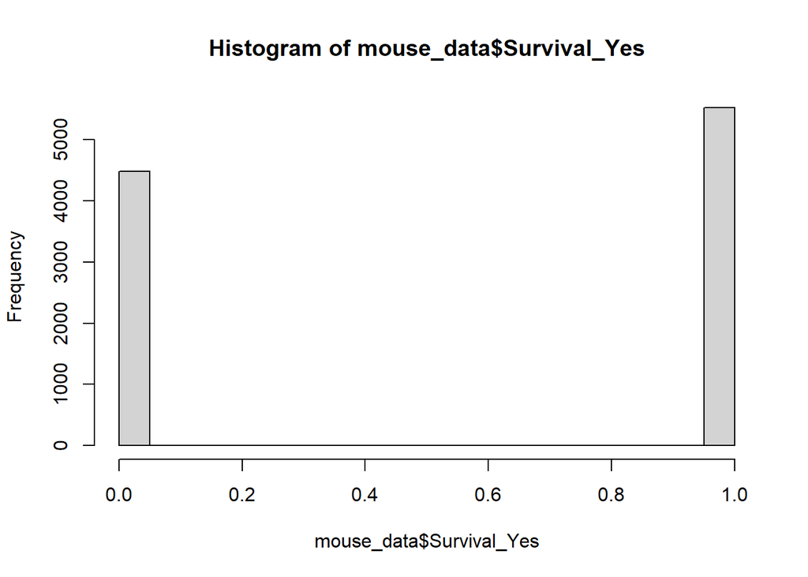

```r
hist(mouse_data$Survival_Yes)
```

```r
# The mouse survival data follows a binomial distribution because survival is a binary outcome (0 = No, 1 = Yes)
```

## Question 1: Mouse Survival

### Part 2 - Statistical Test for Survival Variation

A logistic regression model was used to look at how survival varies with ground cover, hawk presence, and mouse age.

```r
### Part 2 - Statistical Test for Survival Variation
library(ggplot2)
library(stats)

# Convert categorical variables to factors
mouse_data$Ground_Cover <- as.factor(mouse_data$Ground_Cover)
mouse_data$Hawks_Present <- as.factor(mouse_data$Hawks_Present)

# Fit a logistic regression model (GLM) to predict survival
survival_model <- glm(Survival_Yes ~ Ground_Cover + Hawks_Present + Mouse_Age, data = mouse_data, family = binomial)
summary(survival_model)
```

```
##
## Call:
## glm(formula = Survival_Yes ~ Ground_Cover + Hawks_Present + Mouse_Age,
##     family = binomial, data = mouse_data)
##
## Deviance Residuals:
##     Min       1Q   Median       3Q      Max
## -2.0272  -0.7825   0.5473   0.7757   2.0002
##
## Coefficients:
##                       Estimate Std. Error z value Pr(>|z|)
## (Intercept)           -0.90054    0.06393 -14.086  < 2e-16 ***
## Ground_Coverdense_veg  2.85599    0.06222  45.904  < 2e-16 ***
## Ground_Coversome_veg   1.70488    0.06168  27.640  < 2e-16 ***
## Hawks_Presentyes      -0.50963    0.04959 -10.277  < 2e-16 ***
## Mouse_Age             -0.12682    0.02258  -5.617 1.94e-08 ***
## ---
## Signif. codes:  0 '***' 0.001 '**' 0.01 '*' 0.05 '.' 0.1 ' ' 1
##
## (Dispersion parameter for binomial family taken to be 1)
##
##     Null deviance: 13755  on 9999  degrees of freedom
## Residual deviance: 11039  on 9995  degrees of freedom
## AIC: 11049
##
## Number of Fisher Scoring iterations: 4
```

```r
#A logistic regression model was used to look at how survival varies with ground cover, hawk presence, and mouse age.
```

## Question 2: ESCA Trees

### Part 1 - Subset Data for “Ulmus parvifolia”

```r
### Part 1 - Subset Data for "Ulmus parvifolia"
library(dplyr)
file_path <- "~/Downloads/ESCA_Trees.csv"
esca_data <- read.csv(file_path)
# Check structure of dataset
str(esca_data)
```

```
## 'data.frame':    2886 obs. of  17 variables:
##  $ year                          : int  1999 1999 1999 1999 1999 1999 1999 1999 1999 1999 ...
##  $ site_code                     : chr  "AB181" "AB181" "AB181" "AB181" ...
##  $ vegetation_scientific_name    : chr  "Citrus sinensis" "Citrus sinensis" "Citrus sinensis" "Citrus sinensis" ...
##  $ common_name                   : chr  "Orange, Arizona sweet orange, Navel Orange" "Orange, Arizona sweet orange, Navel Orange" "Orange, Arizona sweet orange, Navel Orange" "Orange, Arizona sweet orange, Navel Orange" ...
##  $ vegetation_shape_code         : chr  "rounded" "rounded" "rounded" "rounded" ...
##  $ vegetation_classification_code: chr  "accent" "accent" "accent" "accent" ...
##  $ height_measured               : num  NA NA NA NA NA NA NA NA NA NA ...
##  $ height_distance               : num  9.6 7 5 12 7 13.5 4 6 9 3 ...
##  $ height_degree_up              : num  16 16 20 15 33 12 20 32 32 33 ...
##  $ height_degree_down            : num  10 13 19 8 8 13 21 17 10 28 ...
##  $ bottom_canopy_height          : num  1.4 1.3 0.45 1.07 1.7 2 1.1 1.7 2 1.2 ...
##  $ crown_deg_down                : int  0 0 0 0 0 0 0 0 0 0 ...
##  $ width_ns                      : num  6.8 6.4 2.5 7 4.5 6.4 2.8 4.5 9.4 2.3 ...
##  $ width_ew                      : num  6.6 6.3 2.6 7 4.7 6.3 1.7 6.3 9.5 2.1 ...
##  $ stem_diameter                 : num  10 8 20.5 15 20 NA 1.8 10 13 2 ...
##  $ stem_height                   : chr  "dbh" "dbh" "dgh" "dbh" ...
##  $ stem_count                    : int  5 5 2 4 1 1 5 3 7 4 ...
```

```r
# Subset data for species "Ulmus parvifolia"
ulmus_data <- esca_data %>% filter(vegetation_scientific_name == "Ulmus parvifolia")

# Display
head(ulmus_data)
```

```
##   year site_code vegetation_scientific_name common_name vegetation_shape_code
## 1 1999      X191           Ulmus parvifolia Chinese Elm               rounded
## 2 1999      X191           Ulmus parvifolia Chinese Elm               rounded
## 3 1999      X191           Ulmus parvifolia Chinese Elm               rounded
## 4 1999      X191           Ulmus parvifolia Chinese Elm               rounded
## 5 1999      X191           Ulmus parvifolia Chinese Elm               rounded
## 6 2000      R101           Ulmus parvifolia Chinese Elm             spreading
##   vegetation_classification_code height_measured height_distance
## 1                         accent              NA               4
## 2                         accent              NA               5
## 3                         accent              NA               5
## 4                         accent              NA               5
## 5                         accent              NA               4
## 6                         street              NA               8
##   height_degree_up height_degree_down bottom_canopy_height crown_deg_down
## 1               24                 22                 1.30              0
## 2               25                 16                 1.40              0
## 3               19                 19                 1.40              0
## 4               25                 16                 1.70              0
## 5               18                 23                 1.40              0
## 6               25                -10                 2.36              0
##   width_ns width_ew stem_diameter stem_height stem_count
## 1      3.6      3.5           6.0         dbh          1
## 2      3.4      3.7           7.0         dbh          1
## 3      3.3      3.2           5.6         dbh          1
## 4      2.7      3.3           6.5         dbh          1
## 5      3.7      3.7           7.0         dbh          1
## 6      5.4      5.4          11.2         dbh          1
```

## Question 2: ESCA Trees

### Part 2 - Determine Distribution of “Height Measured”

It follows a nomral distribution. 0.4732 of a P value is good enough.

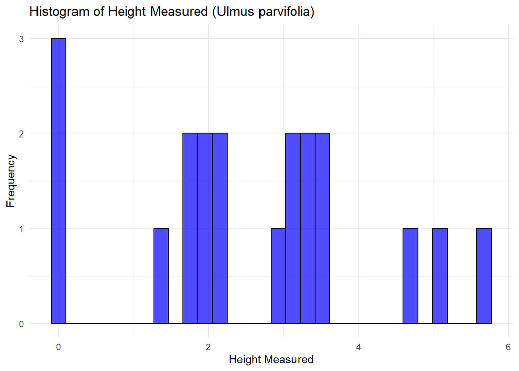

```r
library(fitdistrplus)
library(dplyr)
library(ggplot2)
# Subset data for "Ulmus parvifolia"
ulmus_data <- esca_data %>% filter(vegetation_scientific_name == "Ulmus parvifolia")

#loads of missing values

# Plot histogram
ggplot(data = ulmus_data, aes(x = height_measured)) +
  geom_histogram(bins = 30, fill = "blue", color = "black", alpha = 0.7) +
  labs(title = "Histogram of Height Measured (Ulmus parvifolia)",
       x = "Height Measured",
       y = "Frequency") +
  theme_minimal()
```

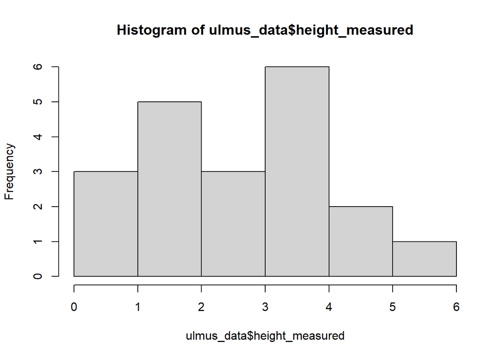

```r
hist(ulmus_data$height_measured)
```

```r
# Perform Shapiro-Wilk test
shapiro_test <- shapiro.test(ulmus_data$height_measured)

# Print test results
print(shapiro_test)
```

```
##
##  Shapiro-Wilk normality test
##
## data:  ulmus_data$height_measured
## W = 0.95632, p-value = 0.4732
```

## Question 2: ESCA Trees

### Part 3 - Comparing Height by Vegetation Shape and Classification Code

The linear model analysis indicates that height (height_measured) is significantly influenced by vegetation classification, with naturalized trees being shorter on average (p = 0.00889, estimate = -1.9071) and shade trees being taller (p = 0.02176, estimate = 2.9429). The upright shape classification shows a marginal effect (p = 0.06765), while foundation and street classifications are not significant, meaning they do not strongly impact height. The model explains 71% of the variation (R² = 0.7095), and the F-statistic (5.861, p = 0.005742) confirms its overall significance. This suggests that some vegetation classifications affect height, and that others do not play a meaningful role.

```r
# Linear model: Height ~ Vegetation Shape + Vegetation Classification
# Linear model: Height ~ Vegetation Shape + Vegetation Classification
UP_LM <- lm(height_measured ~ vegetation_shape_code + vegetation_classification_code,
            data = ulmus_data)
# Display summary of the linear model
summary(UP_LM)
```

```
##
## Call:
## lm(formula = height_measured ~ vegetation_shape_code + vegetation_classification_code,
##     data = ulmus_data)
##
## Residuals:
##     Min      1Q  Median      3Q     Max
## -1.4333 -0.7950  0.0000  0.6554  1.5667
##
## Coefficients:
##                                           Estimate Std. Error t value Pr(>|t|)
## (Intercept)                                 2.7571     0.3948   6.983 1.47e-05
## vegetation_shape_codeupright                2.2429     1.1167   2.008  0.06765
## vegetation_classification_codefoundation    0.3629     1.1167   0.325  0.75083
## vegetation_classification_codenaturalized  -1.9071     0.6117  -3.118  0.00889
## vegetation_classification_codeshade         2.9429     1.1167   2.635  0.02176
## vegetation_classification_codestreet       -1.8667     1.2062  -1.548  0.14769
##
## (Intercept)                               ***
## vegetation_shape_codeupright              .
## vegetation_classification_codefoundation
## vegetation_classification_codenaturalized **
## vegetation_classification_codeshade       *
## vegetation_classification_codestreet
## ---
## Signif. codes:  0 '***' 0.001 '**' 0.01 '*' 0.05 '.' 0.1 ' ' 1
##
## Residual standard error: 1.045 on 12 degrees of freedom
##   (89 observations deleted due to missingness)
## Multiple R-squared:  0.7095, Adjusted R-squared:  0.5884
## F-statistic: 5.861 on 5 and 12 DF,  p-value: 0.005742
```

## Question 2: ESCA Trees

### Part 4 - Comparing Height Between Vegetation Shape and Classification Code Combinations

The ANOVA results indicate that vegetation classification code significantly affects height (p = 0.00627).Suggesting different vegetation classifications lead to significant height variations.

```r
# ANOVA to compare height across vegetation shape and classification code combinations
height_anova <- aov(height_measured ~ vegetation_shape_code * vegetation_classification_code, data = ulmus_data)

# Display ANOVA results
summary(height_anova)
```

```
##                                Df Sum Sq Mean Sq F value  Pr(>F)
## vegetation_shape_code           1   5.16   5.160   4.729 0.05038 .
## vegetation_classification_code  4  26.82   6.705   6.144 0.00627 **
## Residuals                      12  13.10   1.091
## ---
## Signif. codes:  0 '***' 0.001 '**' 0.01 '*' 0.05 '.' 0.1 ' ' 1
## 89 observations deleted due to missingness
```

## Question 3: HMF Plant Composition – Comparing Maple Composition

### Part 1 - Subset Data for Adult Maple Trees

```r
### Part 1 - Subset Data for Adult Maple Trees
# Load necessary libraries
library(dplyr)

# Load dataset
file_path <- "~/Downloads/HMF_Plant_Comp_Data.csv"
hmf_data <- read.csv(file_path)

# Subset to include only adult maple trees (Genus Acer, no seedlings)
maple_trees <- hmf_data %>%
  filter(grepl("^Acer\\.", Species) & !grepl("seedling", Species))

# Display first few rows
head(maple_trees)
```

```
##   Year Time_Period Site          Species Count.Cover
## 1 1949    Period_1    1 Acer.platanoides           0
## 2 1949    Period_1    1      Acer.rubrum           0
## 3 1949    Period_1    1   Acer.saccharum           0
## 4 1949    Period_1    2 Acer.platanoides           0
## 5 1949    Period_1    2      Acer.rubrum           0
## 6 1949    Period_1    2   Acer.saccharum           0
```

## Question 3: HMF Plant Composition – Comparing Maple Composition

### Part 2 - Two-Way ANOVA: Count Variation by Species and Time Period

```r
### Part 2 - Two-Way ANOVA: Count Variation by Species and Time Period
library(dplyr)
maple_data <- hmf_data %>%
  filter(grepl("^Acer", Species, ignore.case = TRUE) & !grepl("seedling", Species, ignore.case = TRUE))

# Run Two-Way ANOVA on Count.Cover by Species and Time_Period
anova_model <- aov(Count.Cover ~ Species * Time_Period, data = maple_data)

# Display ANOVA summary
summary(anova_model)
```

```
##                      Df Sum Sq Mean Sq F value   Pr(>F)
## Species               2   1964   982.2  10.680 3.36e-05 ***
## Time_Period           3   1960   653.5   7.106 0.000127 ***
## Species:Time_Period   6   3924   654.0   7.111 4.43e-07 ***
## Residuals           288  26485    92.0
## ---
## Signif. codes:  0 '***' 0.001 '**' 0.01 '*' 0.05 '.' 0.1 ' ' 1
```

## Question 3: HMF Plant Composition – Comparing Maple Composition

### Part 3 - Visualization: Red Maple Count in Time Period 1 vs. Time Period 4

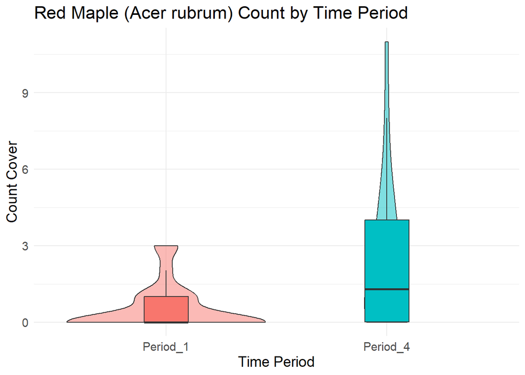

```r
### Part 3 - Visualization: Red Maple Count in Time Period 1 vs. Time Period 4
library(ggplot2)
library(dplyr)
# Subset data for Red Maple (Acer rubrum) in Time Periods 1 and 4
red_maple_data <- hmf_data %>%
  filter(Species == "Acer.rubrum" & Time_Period %in% c("Period_1", "Period_4"))

# Create the figure
ggplot(red_maple_data, aes(x = Time_Period, y = Count.Cover, fill = Time_Period)) +
  geom_violin(alpha = 0.5) +   # Show distribution
  geom_boxplot(width = 0.2, outlier.shape = NA) +  # Add boxplot for clarity
  labs(title = "Red Maple (Acer rubrum) Count by Time Period",
       x = "Time Period",
       y = "Count Cover") +
  theme_minimal() +  # Clean theme for better readability
  theme(legend.position = "none", text = element_text(size = 14))
```

## Question 4: HMF Community Analysis

```r
library(vegan)
library(dplyr)
library(tidyr)
library(ggplot2)
#PART 1
# Load dataset
file_path <- "~/Downloads/HMF_Plant_Comp_Data.csv"
HMF_Trees <- read.csv(file_path)

# Restructure Data for NMDS
HMF_Wide <- HMF_Trees %>%
  pivot_wider(names_from = Species, values_from = Count.Cover, values_fill = list(Count.Cover = 0))

# Remove first three columns to keep only numeric species data
HMF_Wide_NMDS <- HMF_Wide[, -c(1,2,3)]

#PART 2
# Perform NMDS using only species abundance data
HMF_NMDS <- metaMDS(HMF_Wide_NMDS, k = 2, trymax = 1000)
```

```
## Square root transformation
## Wisconsin double standardization
## *** Best solution was not repeated -- monoMDS stopping criteria:
##     25: no. of iterations >= maxit
##    970: stress ratio > sratmax
##      5: scale factor of the gradient < sfgrmin
```

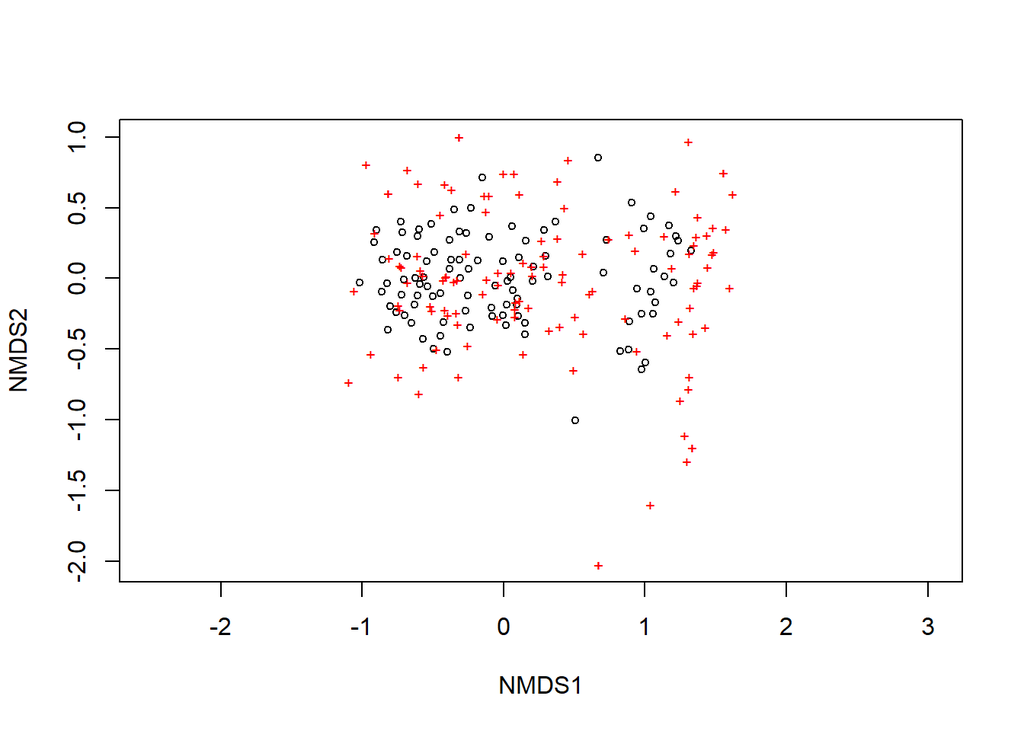

```r
# Plot the NMDS result
plot(HMF_NMDS)
```

```r
# Display NMDS points
HMF_NMDS$points
```

```
##             MDS1         MDS2
## 1   -0.493954226 -0.498726025
## 2   -0.628393518 -0.185342396
## 3   -0.819991681 -0.364214662
## 4   -0.621557147  0.003322076
## 5   -0.802613104 -0.200189650
## 6   -0.650177618 -0.316691956
## 7   -0.562103002  0.004915578
## 8   -0.716819170  0.327548980
## 9   -0.572492559 -0.427447839
## 10  -0.760714796 -0.239778581
## 11  -0.916100886  0.256777307
## 12  -0.718620907 -0.114955130
## 13  -0.500052717 -0.125800691
## 14  -0.425637908 -0.309996245
```

[output cut: 94 more lines]

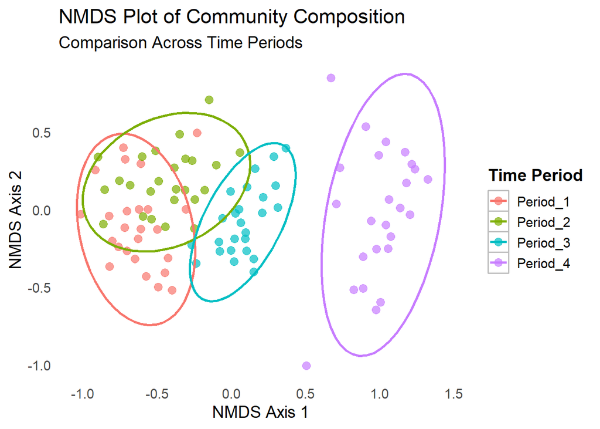

```r
#Part 3
# Extract metadata (Site, Time_Period) for plotting
HMF_Plotting <- HMF_Wide[, c(1:3)]  # Select first three columns (Site, Time_Period, etc.)

# Add NMDS coordinates to metadata
HMF_Plotting$NMDS_X <- HMF_NMDS$points[, 1]
HMF_Plotting$NMDS_Y <- HMF_NMDS$points[, 2]

# Create NMDS plot
print(ggplot(data = HMF_Plotting, aes(x = NMDS_X, y = NMDS_Y, col = Time_Period)) +
  geom_point(size = 3, alpha = 0.7) +
  stat_ellipse(aes(group = Time_Period), linewidth = 1) +
  labs(title = "NMDS Plot of Community Composition",
       subtitle = "Comparison Across Time Periods",
       x = "NMDS Axis 1",
       y = "NMDS Axis 2",
       color = "Time Period") +
  theme_minimal(base_size = 14) +
  theme(legend.position = "right",
        legend.title = element_text(face = "bold"),
        legend.key = element_rect(fill = "white", color = "gray"),
        panel.grid = element_blank()))
```